# Influence Variables on the Market Value of Football Players

João Leite

03/29/2023

The aim of this analysis is to understand which performance variables of football players most affect their price. This study does not aim to find static truths that can be applied to all football players in any market around the world and in all times. Instead, the goal is to highlight the importance of considering football players as financial assets and that there are “hidden” variables on the field that affect their price, and being able to identify players who are cheaper than they should be can bring competitive advantages to football market executives.

Thus, considering the top 30 football players in the world in 2022, according to FIFA, and an additional 16 players who were listed as the most valuable in the world according to Transfermarkt (as of the date of this study), we obtained a list of 46 players to use as a basis for analysis.

From this list, performance data per season for these players was obtained from FBref and combined with the market values from Transfermarkt.

Finally, I will perform a linear regression analysis with a stepwise procedure to try to see which variables, in this database, have a direct impact on player pricing.

```
## Rows: 313
## Columns: 87
## $ ID                          <dbl> 1, 1, 1, 1, 1, 1, 1, 1, 1, 1, 1, 1, 1, 1, ~
## $ PlayerName                  <chr> "Karim Benzema", "Karim Benzema", "Karim B~
## $ Year                        <dbl> 2005, 2006, 2007, 2008, 2009, 2010, 2011, ~
## $ Birth                       <dbl> 1987, 1987, 1987, 1987, 1987, 1987, 1987, ~
## $ Age                         <dbl> 18, 19, 20, 21, 22, 23, 24, 25, 26, 27, 28~
## $ Country                     <fct> França, França, França, França, França, Fr~
## $ StrongFoot                  <fct> direito, direito, direito, direito, direit~
## $ Position                    <fct> Atacante, Atacante, Atacante, Atacante, At~
## $ `Height(m)`                 <dbl> 1.85, 1.85, 1.85, 1.85, 1.85, 1.85, 1.85, ~
## $ MarketValue                 <dbl> 4.50e+05, 2.00e+06, 1.50e+07, 2.75e+07, 3.~
## $ MatchesPlayed               <dbl> 6, 14, 24, 43, 44, 32, 41, 45, 40, 46, 42,~
## $ MatchesStarted              <dbl> 1, 5, 14, 39, 39, 17, 24, 36, 25, 45, 41, ~
## $ MinPlayed                   <dbl> 112, 609, 1257, 3157, 3460, 1627, 2269, 30~
```

[output cut: 74 more lines]

As we have qualitative variables, the first step is to generate dummy variables from those variables

“Dummy variables” are a statistical technique used to represent qualitative or categorical variables in a regression analysis. It involves converting non-numeric data into numeric data, which can be used in a regression model.

After this step, we proceed with the construction of our regression model.

```
##
## Call:
## lm(formula = MarketValue ~ . - ID - PlayerName, data = PlayersData_dummies)
##
## Residuals:
##       Min        1Q    Median        3Q       Max
## -37501943 -11149820   -783873   9753750  79249107
##
## Coefficients: (9 not defined because of singularities)
##                               Estimate Std. Error t value Pr(>|t|)
## (Intercept)                   75346197 1359421014   0.055 0.955850
## Year                           1158517     807382   1.435 0.152740
## Birth                         -1123814     683723  -1.644 0.101679
## Age                                 NA         NA      NA       NA
## `Height(m)`                  -87671439   42952186  -2.041 0.042436 *
## MatchesPlayed                    59499     419480   0.142 0.887337
## MatchesStarted                -1099239    1125616  -0.977 0.329861
## MinPlayed                         9459      17706   0.534 0.593746
## Goals                           324581     438735   0.740 0.460207
## Assist                          907216     551182   1.646 0.101209
## YellowCards                    -429693     592415  -0.725 0.469028
## RedCard                       -1073504    3276329  -0.328 0.743486
## ShotsDone                       -49895      58092  -0.859 0.391343
## ShotsTarget                     427844     194777   2.197 0.029099 *
## FreeKickShots                  1554676     740717   2.099 0.036973 *
## PenaltyShots                    942498    1085020   0.869 0.385992
## Tackles                         387904     660473   0.587 0.557598
## TacklesWon                      -59451     205191  -0.290 0.772291
## TacklesDef                     -730146     712533  -1.025 0.306626
## TacklesMid                       71454     829660   0.086 0.931446
## TacklesAtt                          NA         NA      NA       NA
## DribllersTackled               -313673     608808  -0.515 0.606915
## ChallengesLost                 -135215     240245  -0.563 0.574133
## Blocks                          371115     358904   1.034 0.302266
## ShotsBlocked                    196738     854951   0.230 0.818216
## PassesBlocked                       NA         NA      NA       NA
## Interceptions                   116284     202209   0.575 0.565834
## Clearances                     -226433     260680  -0.869 0.386004
## Erroes                         1253353    2476445   0.506 0.613289
## ShotCreationAct                1861307    1918050   0.970 0.332909
```

[output cut: 64 more lines]

```
## Country_Polónia              -24293383    8236270  -2.950 0.003528 **
## Country_Portugal              -2916219    6935480  -0.420 0.674548
## Country_Senegal              -11619462    9230087  -1.259 0.209418
## Country_Sérvia                 4161700   14318015   0.291 0.771585
## Country_Uruguai                7436909    9105167   0.817 0.414942
## StrongFoot_ambos                    NA         NA      NA       NA
## StrongFoot_esquerdo            1999954    8039908   0.249 0.803785
## Position_Defensor              3443384   11051618   0.312 0.755662
## `Position_Meio-Campo`         -1082471    5691464  -0.190 0.849335
## ---
## Signif. codes:  0 '***' 0.001 '**' 0.01 '*' 0.05 '.' 0.1 ' ' 1
##
## Residual standard error: 19740000 on 219 degrees of freedom
## Multiple R-squared:  0.8176, Adjusted R-squared:  0.7401
## F-statistic: 10.55 on 93 and 219 DF,  p-value: < 2.2e-16
```

As we identified many variables that do not have statistical significance, the next step is to perform a stepwise procedure to eliminate them and determine which combination of variables best helps us predict the market value of the players.

A stepwise procedure is a statistical method used to select the most important independent variables to include in the final regression model. It works by iteratively adding or removing independent variables from the model based on their statistical significance, until the model includes only the most important variables.

```
##
## Call:
## lm(formula = MarketValue ~ `Height(m)` + ShotsTarget + FreeKickShots +
##     Blocks + Toches + TochesDef + TochesMid + TochesLiveBall +
##     SuccessfulDribbles + DribblesAttempt + Dispossessed + TeamGolsWhileInfield +
##     TeamGolsAllowedWhileInfield + FreekickPasses + ThroughBalls +
##     Crosses + CrossesAttempt + Country_Argélia + Country_Colômbia +
##     `Country_Costa do Marfim` + Country_Espanha + Country_França +
##     Country_Polónia, data = PlayersData_dummies)
##
## Residuals:
##       Min        1Q    Median        3Q       Max
## -57242484 -10959887  -1271991  10552486  89082720
##
## Coefficients:
##                              Estimate Std. Error t value Pr(>|t|)
## (Intercept)                  96863058   40822537   2.373 0.018309 *
## `Height(m)`                 -50039029   22650995  -2.209 0.027950 *
## ShotsTarget                    599242      46224  12.964  < 2e-16 ***
## FreeKickShots                 1516771     466384   3.252 0.001281 **
## Blocks                         567793     123239   4.607 6.13e-06 ***
## Toches                       -2294033     833052  -2.754 0.006265 **
## TochesDef                       58999      12633   4.670 4.61e-06 ***
## TochesMid                       73646      12357   5.960 7.33e-09 ***
## TochesLiveBall                2240777     835128   2.683 0.007713 **
## SuccessfulDribbles            -827905     266165  -3.110 0.002054 **
## DribblesAttempt                650656     167326   3.889 0.000125 ***
## Dispossessed                   315719     112477   2.807 0.005341 **
## TeamGolsWhileInfield           346166      55373   6.252 1.46e-09 ***
## TeamGolsAllowedWhileInfield   -371249     113964  -3.258 0.001258 **
## FreekickPasses                -580820     112845  -5.147 4.90e-07 ***
## ThroughBalls                  1286502     226054   5.691 3.10e-08 ***
## Crosses                        110294      29392   3.753 0.000212 ***
## CrossesAttempt                  70817      30115   2.352 0.019365 *
## Country_Argélia             -23556905    5971445  -3.945 0.000100 ***
## Country_Colômbia            -19549949    8080036  -2.420 0.016157 *
## `Country_Costa do Marfim`   -16285357    6674933  -2.440 0.015297 *
## Country_Espanha              15048591    6551851   2.297 0.022343 *
## Country_França               -8416034    3886989  -2.165 0.031192 *
## Country_Polónia             -19987898    5716061  -3.497 0.000545 ***
## ---
## Signif. codes:  0 '***' 0.001 '**' 0.01 '*' 0.05 '.' 0.1 ' ' 1
##
## Residual standard error: 18950000 on 289 degrees of freedom
## Multiple R-squared:  0.7781, Adjusted R-squared:  0.7604
## F-statistic: 44.06 on 23 and 289 DF,  p-value: < 2.2e-16
```

We have observed that our model has become much more efficient and less susceptible to overfitting, allowing us to identify the variables that actually impact the market value of the players.

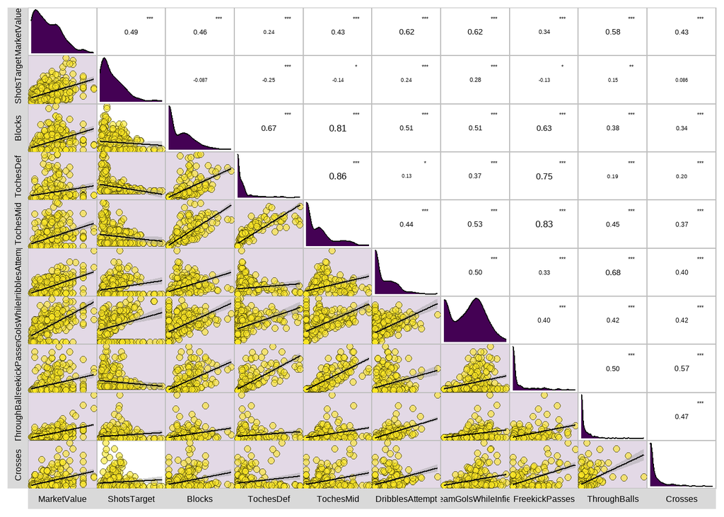

Now we performed the Shapiro-Francia test to check if the errors of our model follow a normal distribution. If so, this means that the regression model is capturing all relevant effects and that the results obtained from it are reliable. In addition, it indicates that the predictor variables used in the model are appropriate for explaining the variation in the dependent variable.

However, if the test indicates otherwise, it means that our regression model is not capturing all relevant effects and that it needs to be revised or improved.

```
##
##  Shapiro-Francia normality test
##
## data:  step_PlayersData$residuals
## W = 0.97569, p-value = 8.84e-05
```

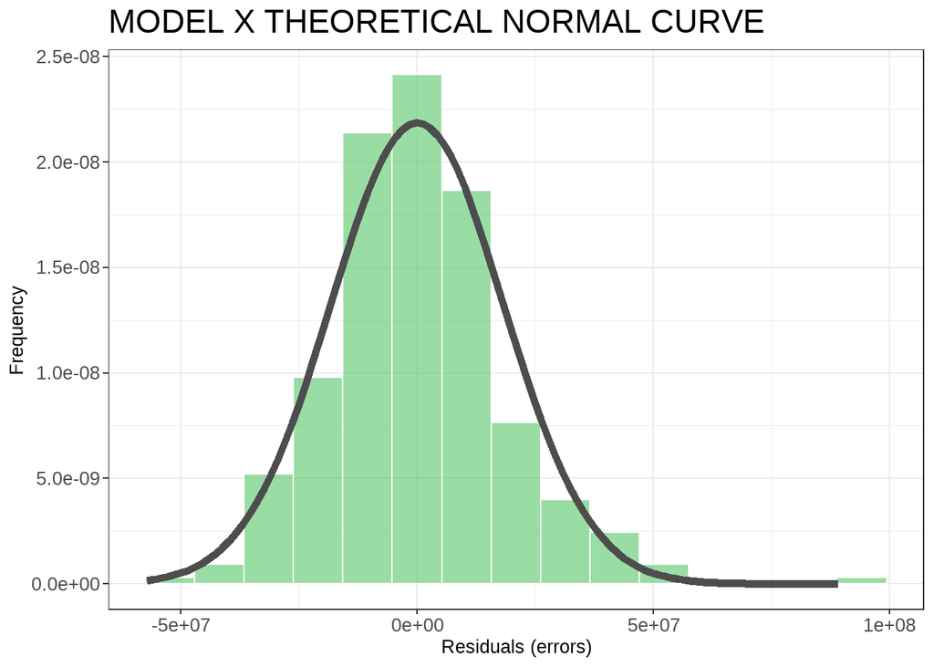

The next step is to check for heteroscedasticity in the data of our model. Generally, if the test value is less than 0.05, there is heteroscedasticity, indicating that there are relevant variables for prediction that were omitted from our model, which can harm the efficiency of regression estimators and make inferences unreliable.

```
##
##  Breusch Pagan Test for Heteroskedasticity
##  -----------------------------------------
##  Ho: the variance is constant
##  Ha: the variance is not constant
##
##                  Data
##  ---------------------------------------
##  Response : MarketValue
##  Variables: fitted values of MarketValue
##
##          Test Summary
##  -------------------------------
##  DF            =    1
##  Chi2          =    35.85639
##  Prob > Chi2   =    2.124107e-09
```

As the value of ‘Prob > Chi2’ was lower than 0.05, this indicates the presence of heteroscedasticity in the model’s data. However, since the aim of this study is to identify the variables that can explain the players’ market value, and not necessarily to predict this value with the highest possible accuracy, and considering that we are limited in terms of data sources to obtain other relevant variables omitted for prediction, we decided to keep the model as it is and proceed with the analysis.

With the model ready, we can now compare the market values generated by the model with the actual market values.

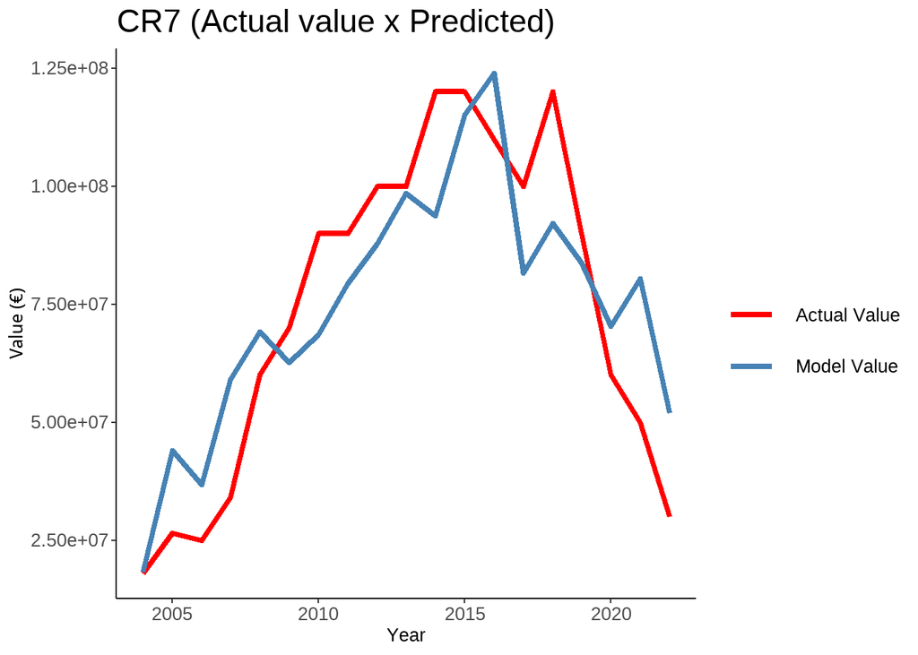

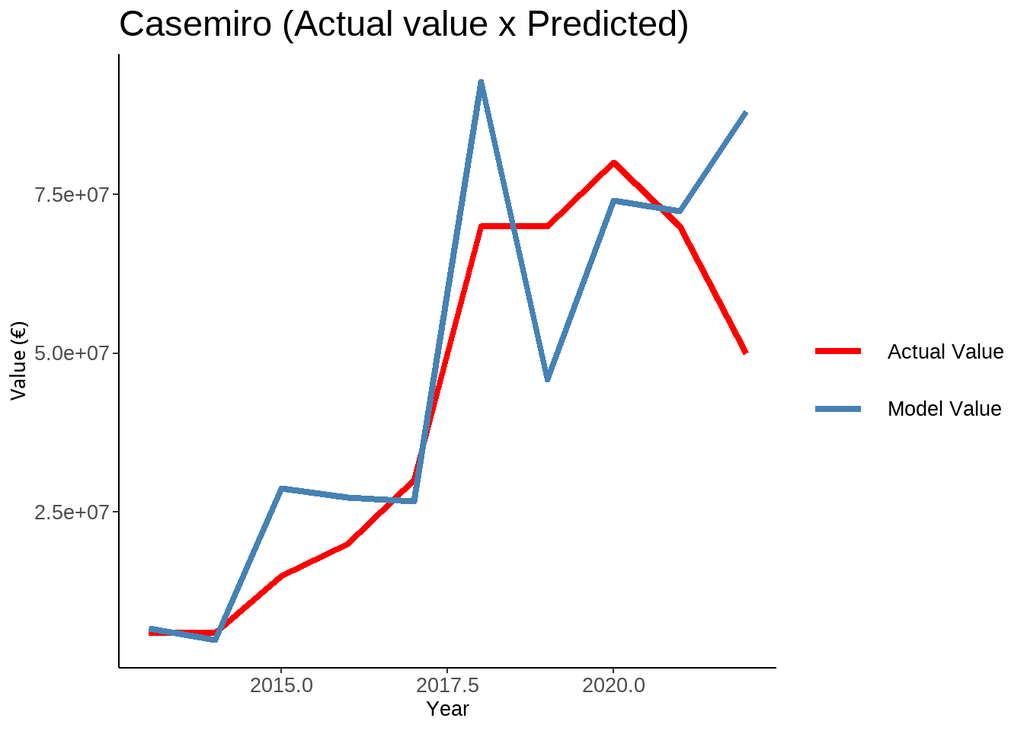

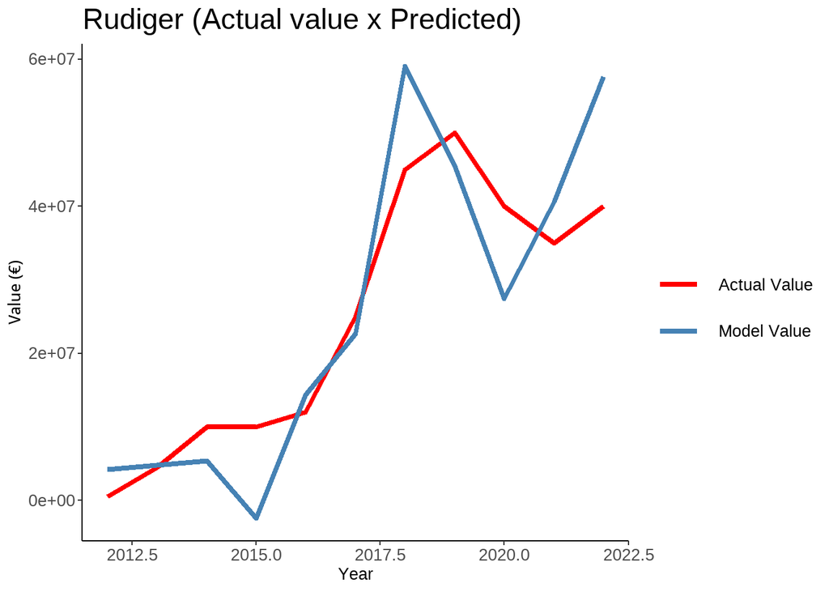

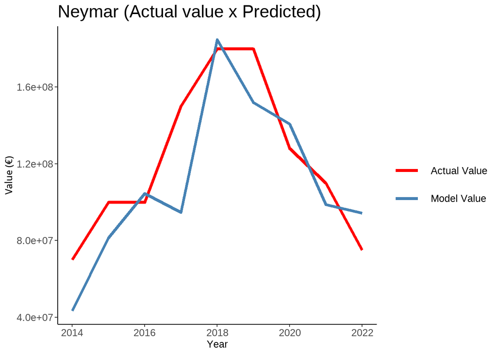

Finally, we have verified that the model has a satisfactory capacity to predict the market value of players and that the chosen variables for the model really influence this value. Therefore, it is important that agents, directors, and anyone involved in the financial aspects of football players pay attention and seek to deepen this type of study, as it demonstrates that some specific variables of player performance (which may or may not be different from the variables that influence performance on the field) can be used for possible profitable deals.

As mentioned at the beginning of this article, this analysis is incipient and was performed with a fraction of the much larger amount of data that can be obtained, both in terms of the quantity of players analyzed and the variables used in the study. However, with this study, we have concluded that these are the main variables (at least with the database we have) and they can serve as a starting point for future analyses that seek to delve deeper into the topic.

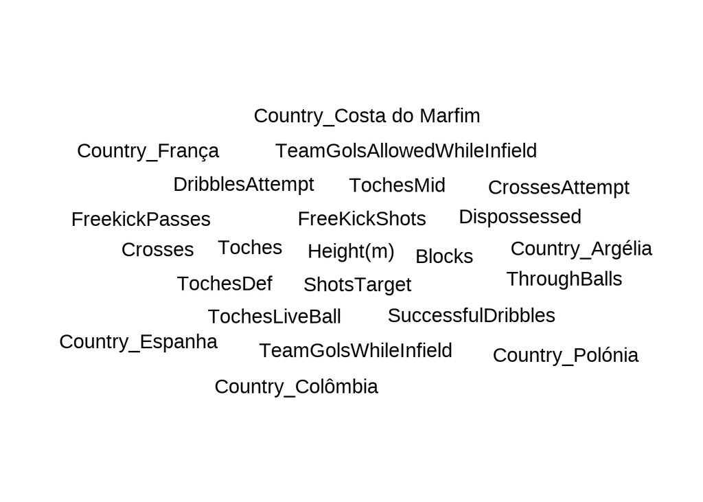

Note: As we transformed the categorical variables into dummy variables, the model separated some specific nationalities. However, I believe that the idea we can take from this is that off-field variables, such as nationality, can significantly influence the market value of players and, therefore, should be considered in decision-making.

If you want to access the codes used in this study, they are available on my Github profile: https://github.com/joao9905.